# NYPD Shooting Incident Data Report

5/22/2021

## Importing the Data

The first step of the process is importing the data. In order to make it reproducible, it is being kept in it’s CSV format. Our variable name will be NYC, since it is both relevant and short.

```r
NYC <- read.csv(url("https://data.cityofnewyork.us/api/views/833y-fsy8/rows.csv"))
SHOT <-read.csv('https://data.cityofnewyork.us/api/views/833y-fsy8/rows.csv?accessType=DOWNLOAD')
head(NYC)
```

```
##   INCIDENT_KEY OCCUR_DATE OCCUR_TIME          BORO PRECINCT JURISDICTION_CODE
## 1    201575314 08/23/2019   22:10:00        QUEENS      103                 0
## 2    205748546 11/27/2019   15:54:00         BRONX       40                 0
## 3    193118596 02/02/2019   19:40:00     MANHATTAN       23                 0
## 4    204192600 10/24/2019   00:52:00 STATEN ISLAND      121                 0
## 5    201483468 08/22/2019   18:03:00         BRONX       46                 0
## 6    198255460 06/07/2019   17:50:00      BROOKLYN       73                 0
##   LOCATION_DESC STATISTICAL_MURDER_FLAG PERP_AGE_GROUP PERP_SEX      PERP_RACE
## 1                                 false
## 2                                 false            <18        M          BLACK
## 3                                 false          18-24        M WHITE HISPANIC
## 4     PVT HOUSE                    true          25-44        M          BLACK
## 5                                 false          25-44        M BLACK HISPANIC
## 6                                 false          45-64        M WHITE HISPANIC
##   VIC_AGE_GROUP VIC_SEX       VIC_RACE X_COORD_CD Y_COORD_CD Latitude Longitude
## 1         25-44       M          BLACK    1037451     193561 40.69781 -73.80814
## 2         25-44       F          BLACK    1006789     237559 40.81870 -73.91857
## 3         18-24       M BLACK HISPANIC     999347     227795 40.79192 -73.94548
## 4         25-44       F          BLACK     938149     171781 40.63806 -74.16611
## 5         18-24       M          BLACK    1008224     250621 40.85455 -73.91334
## 6         25-44       M          BLACK    1009650     186966 40.67983 -73.90843
##                                         Lon_Lat
## 1 POINT (-73.80814071699996 40.697805308000056)
## 2  POINT (-73.91857061799993 40.81869973000005)
## 3 POINT (-73.94547965999999 40.791916091000076)
## 4  POINT (-74.16610830199996 40.63806398200006)
## 5  POINT (-73.91333944399999 40.85454734900003)
## 6  POINT (-73.90842523899994 40.67982701600005)
```

## Description of the Data

In order for us to be able to clean the data we first need a summary and description of it. We can first do this by using the summary command.

```r
summary(NYC)
```

```
##   INCIDENT_KEY        OCCUR_DATE         OCCUR_TIME            BORO
##  Min.   :  9953245   Length:23568       Length:23568       Length:23568
##  1st Qu.: 55317014   Class :character   Class :character   Class :character
##  Median : 83365370   Mode  :character   Mode  :character   Mode  :character
##  Mean   :102218616
##  3rd Qu.:150772442
##  Max.   :222473262
##
##     PRECINCT      JURISDICTION_CODE LOCATION_DESC      STATISTICAL_MURDER_FLAG
##  Min.   :  1.00   Min.   :0.0000    Length:23568       Length:23568
##  1st Qu.: 44.00   1st Qu.:0.0000    Class :character   Class :character
##  Median : 69.00   Median :0.0000    Mode  :character   Mode  :character
##  Mean   : 66.21   Mean   :0.3323
##  3rd Qu.: 81.00   3rd Qu.:0.0000
##  Max.   :123.00   Max.   :2.0000
##                   NA's   :2
##  PERP_AGE_GROUP       PERP_SEX          PERP_RACE         VIC_AGE_GROUP
##  Length:23568       Length:23568       Length:23568       Length:23568
##  Class :character   Class :character   Class :character   Class :character
##  Mode  :character   Mode  :character   Mode  :character   Mode  :character
##
##
##
##
##    VIC_SEX            VIC_RACE          X_COORD_CD         Y_COORD_CD
##  Length:23568       Length:23568       Length:23568       Length:23568
##  Class :character   Class :character   Class :character   Class :character
##  Mode  :character   Mode  :character   Mode  :character   Mode  :character
##
##
##
##
##     Latitude       Longitude        Lon_Lat
##  Min.   :40.51   Min.   :-74.25   Length:23568
##  1st Qu.:40.67   1st Qu.:-73.94   Class :character
##  Median :40.70   Median :-73.92   Mode  :character
##  Mean   :40.74   Mean   :-73.91
##  3rd Qu.:40.82   3rd Qu.:-73.88
##  Max.   :40.91   Max.   :-73.70
##
```

We can see from the summary that the columns are a mix of characters and numbers comprised of 23568 rows and 19 different columns. Each row describes a shooting with information that includes location, date, time, sex and race.

## Tidying and Transforming Data

The first thing we will do to clean and tidy the data is remove any columns we don’t need. This includes the “latitude”, “longitude”, “JURISDICTION_CODE”,X_COORD_CD" and “Y_COORD_CD” columns as well as the “lon_lat” columns. We don’t need these columns to further analyze the data.

```r
NYC <- NYC[, !(names(NYC) %in% c("Latitude","Longitude", "X_COORD_CD", "Y_COORD_CD", "Lon_Lat", "JURISDICTION_CODE"))]
head(NYC)
```

```
##   INCIDENT_KEY OCCUR_DATE OCCUR_TIME          BORO PRECINCT LOCATION_DESC
## 1    201575314 08/23/2019   22:10:00        QUEENS      103
## 2    205748546 11/27/2019   15:54:00         BRONX       40
## 3    193118596 02/02/2019   19:40:00     MANHATTAN       23
## 4    204192600 10/24/2019   00:52:00 STATEN ISLAND      121     PVT HOUSE
## 5    201483468 08/22/2019   18:03:00         BRONX       46
## 6    198255460 06/07/2019   17:50:00      BROOKLYN       73
##   STATISTICAL_MURDER_FLAG PERP_AGE_GROUP PERP_SEX      PERP_RACE VIC_AGE_GROUP
## 1                   false                                                25-44
## 2                   false            <18        M          BLACK         25-44
## 3                   false          18-24        M WHITE HISPANIC         18-24
## 4                    true          25-44        M          BLACK         25-44
## 5                   false          25-44        M BLACK HISPANIC         18-24
## 6                   false          45-64        M WHITE HISPANIC         25-44
##   VIC_SEX       VIC_RACE
## 1       M          BLACK
## 2       F          BLACK
## 3       M BLACK HISPANIC
## 4       F          BLACK
## 5       M          BLACK
## 6       M          BLACK
```

```r
sapply(NYC, function(x) sum(is.na(x)))
```

```
##            INCIDENT_KEY              OCCUR_DATE              OCCUR_TIME
##                       0                       0                       0
##                    BORO                PRECINCT           LOCATION_DESC
##                       0                       0                       0
## STATISTICAL_MURDER_FLAG          PERP_AGE_GROUP                PERP_SEX
##                       0                       0                       0
##               PERP_RACE           VIC_AGE_GROUP                 VIC_SEX
##                       0                       0                       0
##                VIC_RACE
##                       0
```

Last we will transform the date and time to their correct format

```r
date <- NYC
date$OCCUR_DATE <- as.Date(date$OCCUR_DATE,format = "%m/%d/%Y")
date$DAY<- wday(date$OCCUR_DATE, label=TRUE)

h <- function(x) {
  return (as.numeric(strsplit(x,":")[[1]][1]))
}
time_hour <- NYC %>%
  mutate(HOUR = sapply(OCCUR_TIME, h))
hr <- c(paste(c(12,1:11),"AM"), paste(c(12,1:11),"PM"))
time_hour$HOUR <- factor(time_hour$HOUR, level = 0:23, label = hr)
```

In addition to the NYC data set I will also clean and tidy another data frame named “SHOT”. Here I will try a different approach to cleaning, where I will first make everything lower case and then make the boroughs a factor. Lastly I will put the date in the correct date time format.

```r
names(SHOT) <- tolower(names(SHOT))
factor_cols = c('boro')
SHOT[factor_cols] <- lapply(SHOT[factor_cols], as.factor)
SHOT <- SHOT %>%
mutate(occur_date = mdy(occur_date))
summary(SHOT)
```

```
##   incident_key         occur_date          occur_time
##  Min.   :  9953245   Min.   :2006-01-01   Length:23568
##  1st Qu.: 55317014   1st Qu.:2008-12-30   Class :character
##  Median : 83365370   Median :2012-02-26   Mode  :character
##  Mean   :102218616   Mean   :2012-10-03
##  3rd Qu.:150772442   3rd Qu.:2016-02-28
##  Max.   :222473262   Max.   :2020-12-31
##
##             boro         precinct      jurisdiction_code location_desc
##  BRONX        :6700   Min.   :  1.00   Min.   :0.0000    Length:23568
##  BROOKLYN     :9722   1st Qu.: 44.00   1st Qu.:0.0000    Class :character
##  MANHATTAN    :2921   Median : 69.00   Median :0.0000    Mode  :character
##  QUEENS       :3527   Mean   : 66.21   Mean   :0.3323
##  STATEN ISLAND: 698   3rd Qu.: 81.00   3rd Qu.:0.0000
##                       Max.   :123.00   Max.   :2.0000
##                                        NA's   :2
##  statistical_murder_flag perp_age_group       perp_sex
##  Length:23568            Length:23568       Length:23568
##  Class :character        Class :character   Class :character
##  Mode  :character        Mode  :character   Mode  :character
##
##
##
##
##   perp_race         vic_age_group        vic_sex            vic_race
##  Length:23568       Length:23568       Length:23568       Length:23568
##  Class :character   Class :character   Class :character   Class :character
##  Mode  :character   Mode  :character   Mode  :character   Mode  :character
##
##
##
##
##   x_coord_cd         y_coord_cd           latitude       longitude
##  Length:23568       Length:23568       Min.   :40.51   Min.   :-74.25
##  Class :character   Class :character   1st Qu.:40.67   1st Qu.:-73.94
##  Mode  :character   Mode  :character   Median :40.70   Median :-73.92
##                                        Mean   :40.74   Mean   :-73.91
##                                        3rd Qu.:40.82   3rd Qu.:-73.88
##                                        Max.   :40.91   Max.   :-73.70
##
##    lon_lat
##  Length:23568
##  Class :character
##  Mode  :character
##
##
##
##
```

## Visualizations and Analysis

I want to visualize two different things from the data.

1. Is there a borough where shootings happen more frequently?
2. Is there a certain time of day where shootings happen more frequently?

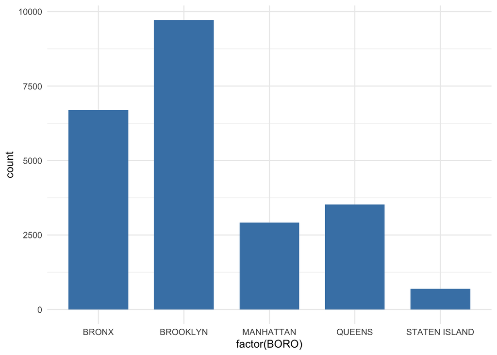

```r
ggplot(NYC, aes(x=factor(BORO)))+
  geom_bar(stat="count", width=0.7, fill="steelblue")+
  theme_minimal()
```

Based off the bar plot we can see that Brooklyn has far more shootings than any other Borough. This raises the question of the frequency of shootings per person that lives there. Based off population data although Brooklyn has the most people residing in it, it still has a higher frequency of shootings other than the Bronx.

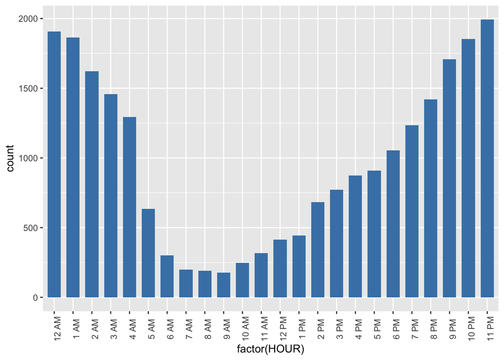

```r
ggplot(time_hour, aes(x=factor(HOUR)))+
  geom_bar(stat="count", width=.7, fill="steelblue")+
  theme(axis.text.x = element_text(angle = 90))
```

Unsurprisingly the most shootings happen late at night. Specifically at 10pm-1am and it reaches its peak at 11pm. I would be curious to see the day of week the most shootings happened paired with the hour as well.

## Modeling

```r
# creating the factor variable
NYC$sex.f <- factor(NYC$VIC_SEX)
is.factor(NYC$sex.f)
```

```
## [1] TRUE
```

```r
summary(lm(PRECINCT ~ sex.f, data = NYC))
```

```
##
## Call:
## lm(formula = PRECINCT ~ sex.f, data = NYC)
##
## Residuals:
##     Min      1Q  Median      3Q     Max
## -65.989 -22.138   2.862  14.862  61.500
##
## Coefficients:
##             Estimate Std. Error t value Pr(>|t|)
## (Intercept)  66.9886     0.5789 115.724   <2e-16 ***
## sex.fM       -0.8503     0.6079  -1.399    0.162
## sex.fU       -8.4886     6.0919  -1.393    0.164
## ---
## Signif. codes:  0 '***' 0.001 '**' 0.01 '*' 0.05 '.' 0.1 ' ' 1
##
## Residual standard error: 27.12 on 23565 degrees of freedom
## Multiple R-squared:  0.0001517,  Adjusted R-squared:  6.681e-05
## F-statistic: 1.787 on 2 and 23565 DF,  p-value: 0.1674
```

```r
boro_tot <- SHOT %>%
group_by(boro, year(occur_date)) %>%
summarize(shootings = n_distinct(incident_key),) %>%
ungroup()
mod <- lm(shootings ~ `year(occur_date)` + boro, data=boro_tot)
summary(mod)
```

```
##
## Call:
## lm(formula = shootings ~ `year(occur_date)` + boro, data = boro_tot)
##
## Residuals:
##      Min       1Q   Median       3Q      Max
## -191.502  -31.991   -1.818   26.871  194.272
##
## Coefficients:
##                     Estimate Std. Error t value Pr(>|t|)
## (Intercept)        18976.133   3499.565   5.422 8.16e-07 ***
## `year(occur_date)`    -9.258      1.738  -5.325 1.19e-06 ***
## boroBROOKLYN         182.467     23.752   7.682 7.62e-11 ***
## boroMANHATTAN       -188.467     23.752  -7.935 2.63e-11 ***
## boroQUEENS          -153.733     23.752  -6.472 1.19e-08 ***
## boroSTATEN ISLAND   -303.133     23.752 -12.762  < 2e-16 ***
## ---
## Signif. codes:  0 '***' 0.001 '**' 0.01 '*' 0.05 '.' 0.1 ' ' 1
##
## Residual standard error: 65.05 on 69 degrees of freedom
## Multiple R-squared:  0.8848, Adjusted R-squared:  0.8765
## F-statistic:   106 on 5 and 69 DF,  p-value: < 2.2e-16
```

Here it can be seen that there is a strong relationship between shootings and the year plus the borough.

## Conclusions and Possible Bias

Fortunately both my questions could be answered by visualizing and plotting the data. 1. Brooklyn has the most shootings by far, but I also wondered about frequency of shootings. A quick google search showed the Brooklyn population was almost twice the size of the Bronx. Even after accounting for the size of populations the Bronx was a close second in frequency. 2. Based off plotting the shooting count vs. time of day, it could easily been seen that nighttime had the vast majority of shootings. The number of cases plateaued from around 7am-9am and then began to rise again until it peaked at 11pm.

A possible bias that could be present in the data is how heavily an area is policed. If there is a stronger police presence in an area, that could result in a higher amount of incidents reported. My own personal fear of being out alone at night resulted in the analysis of the time of the shootings, which is a potential bias.